# Intratumoral T-cell and B-cell receptor architecture associates with distinct immune tumor microenvironment features and clinical outcomes of anti-PD-1/L1 immunotherapy

¶ Uni and Multivariate survival analysis for TCGA data ¶

Aimilia Schina

First created on 9 October 2019. Updated on 20 February 2024

```r
## Clear R-workspace
# rm(list=ls(all=TRUE))

## Close all graphic devices
graphics.off()
#####################
### Load packages ###
#####################
library(pacman)

pacman::p_load(extrafont,DT,dplyr,tibble,survminer,survival, ggplot2, hrbrthemes, grid, gridExtra, cowplot,Amelia, data.table, tidytidbits,survivalAnalysis,gtsummary,purrr, plyr,boot,pec,mosaic,boot.pval,stringr)

extrafont::loadfonts(device="win")
windowsFonts(sans="Palatino Linotype")
loadfonts(device="win")
loadfonts(device="postscript")
```

```r
###########################
### Main analysis paths ###
###########################
# Main
scriptsPath <- paste0("scripts/")
scriptsMainPath<- paste0(scriptsPath, "main/")
scriptsFunctionsPath <- paste0(scriptsPath,"functions/")
projectDataPath <- paste0("data/")
# Input
tcgaInputData <- paste0(projectDataPath,"TCGA/")
antiPDL1publicInputData <- paste0(projectDataPath,"antiPD(L)1_public/")
otherInputData <- paste0(projectDataPath,"other/")
referenceInputData <- paste0(projectDataPath,"reference/")
# Output
projectOutDataPath <- paste0("output/data_files/")
tcgaIntermediateData <- paste0(projectOutDataPath,"TCGA/")
# antiPDL1publicIntermediateData <- paste0(projectOutDataPath,"antiPD(L)1_public/")

# Session/dependencies
sessionInfoPath <- paste0("session_info/")

######################################
## Create intermediate output paths ##
######################################
if (!dir.exists(paste0(projectOutDataPath,"survival/"))) {dir.create(paste0(projectOutDataPath,"survival/"))}


##################################
### LOAD SOURCE FUNCTIONS FILE ###
##################################
source(paste0(scriptsFunctionsPath,"TCGA_survival_analysis_functions.R"), local = T)


#####################
### File suffixes ###
#####################
Rdata.suffix <- ".RData"
```

# 1 Data loading

Load TCGA primary tumor clinical biomarker metadata data tables, constructed in **A_06_tcga_clinical_biomarker_metadata.RMD** analyses.

```r
tcgaData.tp <- loadRData(paste0(tcgaIntermediateData, "tcga.tp.Filt.final",Rdata.suffix)) %>% as.data.frame()
# tcga.drug.notICI <-loadRData(paste0(tcgaIntermediateData, "tcga.tp.nonFilt.final_ICI4Tissues.RData"))
tcga.drug.ici.To.Exclude2 <- loadRData(paste0(tcgaIntermediateData, "tcga_patientsNOTici_toEXCLUDE_4Tissues.RData"))

# # Compare with init TCGA
# tcgaData.tp.init <- loadRData(paste0("C:/Users/aimilia/BIOINF/1_DATA/3_TCGA/ClinicalDataTables/RData/", "tcga.tp.Filt.final",Rdata.suffix))
#
# median(tcgaData.tp.init$TIS_sigscore, na.rm = T)
# median(tcgaData.tp$TIS_sigscore, na.rm = T)
#
# median(tcgaData.tp.init$BCR_Richness, na.rm = T)
# median(tcgaData.tp$BCR_Richness, na.rm = T)
```

```r
table(tcgaData.tp$project)
```

```
##
##           ACC          BLCA          BRCA     BRCA_Her2 BRCA_LuminalA BRCA_LuminalB   BRCA_Normal       BRCA_TN          CESC          CHOL
##            92           412          1099            82           568           217           140           191           308            45
##          COAD      COAD_MSI  COAD_MSI_low      COAD_MSS          DLBC          ESCA           GBM          HNSC          KICH          KIRC
##           461            78            80           275            50           185           611           528           113           537
##          KIRP          LAML           LGG          LIHC          LUAD          LUSC          MESO            OV          PAAD          PCPG
##           291           200           516           377           583           504            87           606           185           179
##          PRAD          READ          SARC          SKCM          STAD          TGCT          THCA          THYM          UCEC           UCS
##           500           171           261           470           443           150           507           124           560            57
##           UVM
##            80
```

```r
# table(tcga.drug.notICI$project)

# See which patients we need to remove
tcgaData.tp %>% dplyr::filter(bcr_patient_barcode %in% tcga.drug.ici.To.Exclude2) %>% droplevels() %>% distinct()
```

```
##   bcr_patient_barcode project tcga.dataset                 disease_name age_at_initial_pathologic_diagnosis gender  race
## 1        TCGA-DK-AA77    BLCA    TCGA-BLCA Bladder Urothelial Carcinoma                                  61   MALE WHITE
## 2        TCGA-ER-A2NF    SKCM    TCGA-SKCM      Skin Cutaneous Melanoma                                  53   MALE WHITE
## 3        TCGA-GN-A8LN    SKCM    TCGA-SKCM      Skin Cutaneous Melanoma                                  68   MALE WHITE
## 4        TCGA-D9-A148    SKCM    TCGA-SKCM                         <NA>                                  40   MALE WHITE
## 5        TCGA-DA-A1I1    SKCM    TCGA-SKCM                         <NA>                                  55   MALE WHITE
## 6        TCGA-DA-A3F2    SKCM    TCGA-SKCM                         <NA>                                  55   MALE WHITE
## 7        TCGA-DA-A3F5    SKCM    TCGA-SKCM                         <NA>                                  45   MALE WHITE
## 8        TCGA-EE-A2GS    SKCM    TCGA-SKCM                         <NA>                                  28 FEMALE WHITE
##   ajcc_pathologic_tumor_stage   clinical_stage                                   histological_type histological_grade initial_pathologic_dx_year
## 1                    Stage II [Not Applicable] Muscle invasive urothelial carcinoma (pT2 or above)         High Grade                       2013
## 2                  Stage IIIB [Not Applicable]                                                #N/A    [Not Available]                       2010
## 3                   Stage IIC [Not Applicable]                                                #N/A    [Not Available]                       2013
## 4             [Not Available] [Not Applicable]                                                #N/A    [Not Available]                       1999
## 5                   Stage III [Not Applicable]                                                #N/A    [Not Available]                       1996
```

[output cut: 139 more lines]

```r
# Remove patients that received aPD1 immunotherapy.
tcgaData.tp.clean <- tcgaData.tp %>% dplyr::filter(bcr_patient_barcode %notin% tcga.drug.ici.To.Exclude2) %>%
                                      droplevels() %>%
                                      distinct()
dim(tcgaData.tp)
```

```
## [1] 12923   123
```

```r
dim(tcgaData.tp.clean)
```

```
## [1] 12901   123
```

Select rows (patient IDs) for which we have all data:

- TCR richness, from immune pancancer data not clone data
- BCR richness
- Immune infiltration from DanaherZ CIBERSORT : B cells, CD8 T cells, CD4 T cells
- TMB only for TP data not NT
- GEP,
- PD-L1 (not TuTack since it’s not main part of analysis)
- Tumor Purity (ESTIMATE)
- Survival data, OS OS.time

? Do I need complete data? for this analysis

```r
featuresSelected <- c("bcr_patient_barcode", "project","PD_L1","logTMB","BCR_Richness","TCR_Richness",
                      "B_cells.CIBER", "T_Cells_CD8.CIBER", "CD4cells.CIBER","TIS_sigscore", "TumorPurity","OS","OS.time","PFI","PFI.time","age_at_initial_pathologic_diagnosis","gender")

extraFeatures <- c("StromalScore", "ImmuneScore")

featuresIn <- c("TCR_Richness","BCR_Richness","logTMB","PD_L1","TIS_sigscore",
                      "CD8cells", "CD4cells","B_cells",  "TumorPurity")
featuresInLabels <- c("TCR Richness","BCR Richness","logTMB","PD-L1 expression","T-cell inflamed GEP", "CD8+ T cells infiltration","CD4+ T cells infiltration","B cells infiltration",
            "Tumor Purity")
## FOR TP data
tcgaData.tp.sub <- tcgaData.tp.clean %>% dplyr::select(all_of(featuresSelected)) %>% droplevels() %>% distinct()
tcgaData.tp.sub.extra <- tcgaData.tp.clean %>% dplyr::select(all_of(c(featuresSelected,extraFeatures))) %>% droplevels() %>% distinct()

colnames(tcgaData.tp.sub)[7:9] <- gsub(".CIBER","",colnames(tcgaData.tp.sub)[7:9])
colnames(tcgaData.tp.sub)[8] <- "CD8cells"

# Keep rows where at least on of the features of interested is not NA
tcgaData.tp.sub <-tcgaData.tp.sub[rowSums(is.na(tcgaData.tp.sub[,3:11])) != 9,]
tcgaData.tp.sub.extra <-tcgaData.tp.sub.extra[rowSums(is.na(tcgaData.tp.sub.extra[,3:11])) != 9,]
dim(tcgaData.tp.sub)
```

```
## [1] 12385    17
```

```r
dim(tcgaData.tp.sub.extra)
```

```
## [1] 12385    19
```

```r
# There is a duplicated patient
```

Look again at missing values

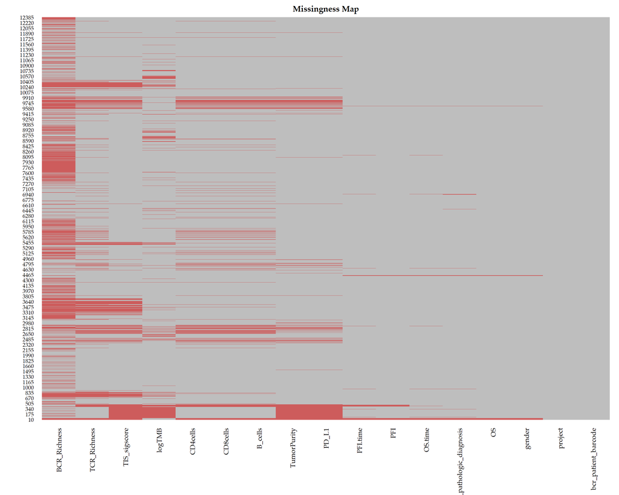

```r
visDF <- tcgaData.tp.sub

missmap(visDF, col=c("Indian red", "grey"), legend=FALSE,x.cex=1,margins=c(9,5))
```

We are not using complete data function since we see that depending on the feature, lots of data are missing.

```r
# Let's summarize the TCGA biospecimen data we just loaded
# Number of patients per project
tcgaData.tp.patient.sub.table <-tcgaData.tp.sub %>% dplyr::select(project,bcr_patient_barcode) %>% group_by(project) %>% distinct() %>% dplyr::summarize(n())

# ## FOR NT data
# tcgaData.nt.compl <- tcgaData.nt %>% dplyr::filter(complete.cases(project, bcr_patient_barcode, TIS_sigscore,TCR_Richness, CD8_T_cells, Exhausted_CD8, Th1_cells, Treg, NK_cells, OS, OS.time))
```

Define TCGA projects included in analysis & subset tables accordingly. Excluding the following TCGA cohorts/molecular subtypes cohorts:

```r
mycancertypes <- levels(as.factor(tcgaData.tp.sub$project))
# mycancertypes <- factor(mycancertypes,levels = mycancertypes)
## Exclude THYM and DLBC
mycancertypes.reduced <- mycancertypes[-which(mycancertypes %in% c("THYM", "DLBC","COAD_MSI_low","BRCA_Her2","BRCA_LuminalA", "BRCA_LuminalB","BRCA","BRCA_Normal","COAD","UCEC","LAML"))]

## TCGA histologies aligned with aPD1 data
mycancertypes.final <- c("SKCM", "KIRC","BLCA","STAD")
# mycancertypes.final <- factor(mycancertypes.final, levels = mycancertypes.final)
## Subset data to reduced types
tcgaData.tp.sub.filt <- tcgaData.tp.sub %>% dplyr::filter(project %in% mycancertypes.reduced) %>% droplevels() %>% as.data.frame()
tcgaData.tp.sub.extra.filt<- tcgaData.tp.sub.extra %>% dplyr::filter(project %in% mycancertypes.reduced) %>% droplevels() %>% as.data.frame()

# Make project a factor with levels
tcgaData.tp.sub.filt$project <- factor(tcgaData.tp.sub.filt$project, levels=mycancertypes.reduced)
tcgaData.tp.sub.extra.filt$project <- factor(tcgaData.tp.sub.extra.filt$project, levels=mycancertypes.reduced)

#CHECK DUPLICATED PATIENTS
which(duplicated(tcgaData.tp.sub.filt$bcr_patient_barcode))
```

```
## integer(0)
```

```r
tcgaData.tp.sub.filt[tcgaData.tp.sub.filt$bcr_patient_barcode==tcgaData.tp.sub.filt$bcr_patient_barcode[which(duplicated(tcgaData.tp.sub.filt$bcr_patient_barcode))],]
```

```
##  [1] bcr_patient_barcode                 project                             PD_L1
##  [4] logTMB                              BCR_Richness                        TCR_Richness
##  [7] B_cells                             CD8cells                            CD4cells
## [10] TIS_sigscore                        TumorPurity                         OS
## [13] OS.time                             PFI                                 PFI.time
## [16] age_at_initial_pathologic_diagnosis gender
## <0 rows> (or 0-length row.names)
```

**Summary Tables of TCGA data for this analysis**

```r
datatable(tcgaData.tp.patient.sub.table, extensions = 'Buttons', options = list(
    dom = 'Bfrtip',
    buttons = c('copy', 'excel', 'csv' ),
    scrollX=TRUE,
    pageLength=15
  ),
  caption = 'Number of patients per project (legacy & harmonized), PRIMARY TUMOR'
)
```

|  | project | n() |
| --- | --- | --- |
| 1 | ACC | 92 |
| 2 | BLCA | 411 |
| 3 | BRCA | 1098 |
| 4 | BRCA_Her2 | 82 |
| 5 | BRCA_LuminalA | 568 |
| 6 | BRCA_LuminalB | 217 |
| 7 | BRCA_Normal | 140 |
| 8 | BRCA_TN | 191 |
| 9 | CESC | 305 |
| 10 | CHOL | 36 |

[output cut: 31 more lines]

In this part we have directly used the Richness results provided in the *The Immune Landscape of Cancer* paper and the immune infiltration provided by Danaher.

# 2 Determining optimal cutpoint for continuous variables

# 3 Cox proportional hazards model & KM PLOTS

Transform OS time unit.

```r
tcgaData.tp.sub.filt$OS.time <-tcgaData.tp.sub.filt$OS.time/(365.24/12)
# tcgaData.tp.compl.filt$PFS.time <-tcgaData.tp.compl.filt$PFS.time/(365.24/12)
```

```r
## HERE we define for which parameters we want to do univariate analysis, and which to include in the multivariate survival analysis.
## PLEASE define name as it is on the csv file, the name needs to be in BRACKETS
features <- featuresIn

## Define which columns include survival data
OS_time <- c("OS.time")
OS_status <- c("OS")
# PFS_time <- c("PFS.time")
# PFS_status <- c("PFS")

# # KM plots labels
# xlabel=".OS.months"

## DEFINE WHICH COLUMNS ARE CATEGORICAL
categ_feats <-featuresIn
## DEFINE WHICH COLUMNS ARE NUMERICAL
# we also add the status and time columns
numeric_feats <-featuresIn
# ## DEFINE IF YOU ARE DOING OS OR PFS
# surv_time <-OS_time
# surv_status <-OS_status
# surv_time_label <- "OS"
# dataDF <- tcgaData.tp.sub.filt

finallabels <- featuresInLabels
names(finallabels) <- featuresIn
```

# 4 Multiple Univariate Analyses - INCLUDING MISSING DATA

Perform Cox regression on right-censored data.

```r
## I want to get results on:

# ALL cohorts together
# SKCM
# KIRC
# BLCA
# STAD

# for UNI and MULTI
# for categorical and continuous
## dont remove missing
```

## 4.1 Categorical

### 4.1.1 Across all cohorts, together

```r
uni.cat.meta <-multiUniSurvival(tcgaData.tp.sub.filt,OS_time,OS_status,"OS", featuresIn,finallabels, removeMis=FALSE, filterCohort=FALSE, filterVar=NULL,cohortSelected=NULL, categTrans=featuresIn, transBy="median")
```

### 4.1.2 All 4 histologies

```r
uni.cat.meta4 <-multiUniSurvival(tcgaData.tp.sub.filt %>% dplyr:: filter(project %in% mycancertypes.final) %>% droplevels() %>% distinct(),OS_time,OS_status,"OS", featuresIn,finallabels, removeMis=FALSE, filterCohort=FALSE, filterVar=NULL,cohortSelected=NULL, categTrans=featuresIn, transBy="median")
```

[1] “>>Final total if we removed missing 830 patients included<<” [1] “>>Final total 1838 patients included<<” TCR_Richness BCR_Richness logTMB PD_L1 TIS_sigscore CD8cells CD4cells B_cells TumorPurity 24.00000000 25.00000000 1.26274422 8.21138646 -0.43433546 0.13270135 0.10572672 0.07023504 0.77377119 [1] “Events per categorical covariate:” TCR_Richness BCR_Richness logTMB PD_L1 TIS_sigscore CD8cells CD4cells B_cells TumorPurity 690 517 474 523 538 690 690 690 523 [1] “>>UNIVARIATE ANALYSIS<<” [1] “>>COLLECTING UNIVARIATE RESULTS<<”

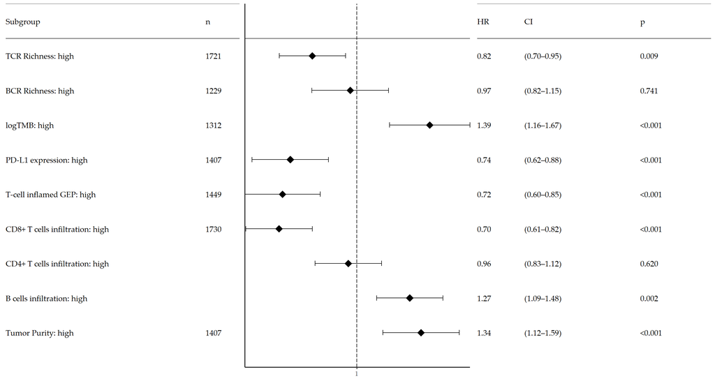

### 4.1.3 4 histologies

```r
uni.cat.4 <- sapply(mycancertypes.final, function(x) multiUniSurvival(tcgaData.tp.sub.filt,OS_time,OS_status,"OS", featuresIn,finallabels, removeMis=FALSE, filterCohort=TRUE, filterVar="project",cohortSelected=x, categTrans=featuresIn, transBy="median"),simplify = FALSE)
```

#### 4.1.3.1 SKCM

[1] “>> Subsetting data to SKCM” [1] “>>Final total if we removed missing 56 patients included<<” [1] “>>Final total 449 patients included<<” TCR_Richness BCR_Richness logTMB PD_L1 TIS_sigscore CD8cells CD4cells B_cells TumorPurity 13.50000000 24.50000000 2.12957648 7.49534093 -0.78502993 0.15434100 0.04178992 0.07206350 0.89359684 [1] “Events per categorical covariate:” TCR_Richness BCR_Richness logTMB PD_L1 TIS_sigscore CD8cells CD4cells B_cells TumorPurity 202 139 29 28 28 202 202 202 28 [1] “>>UNIVARIATE ANALYSIS<<” [1] “>>COLLECTING UNIVARIATE RESULTS<<”

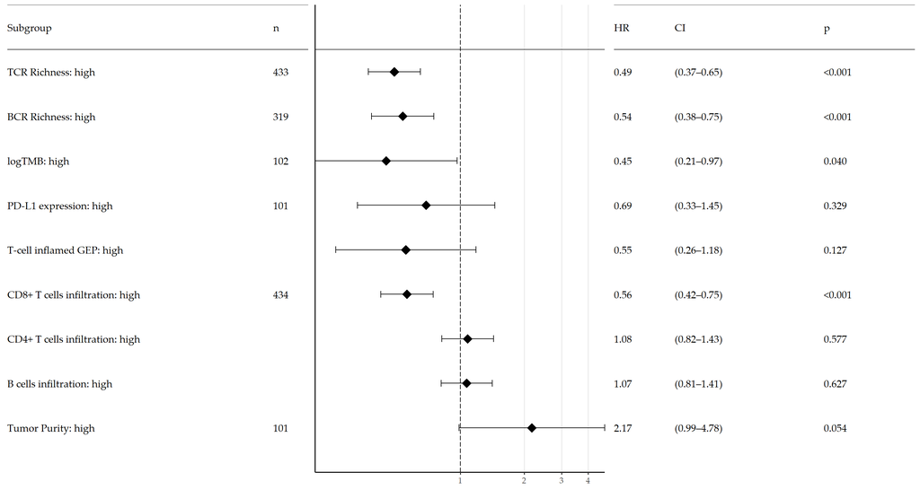

#### 4.1.3.2 KIRC

[1] “>> Subsetting data to KIRC” [1] “>>Final total if we removed missing 182 patients included<<” [1] “>>Final total 535 patients included<<” TCR_Richness BCR_Richness logTMB PD_L1 TIS_sigscore CD8cells CD4cells B_cells TumorPurity 33.0000000 6.0000000 0.8499441 8.4755185 -0.2456237 0.1567477 0.1382614 0.0414214 0.6809039 [1] “Events per categorical covariate:” TCR_Richness BCR_Richness logTMB PD_L1 TIS_sigscore CD8cells CD4cells B_cells TumorPurity 169 108 98 173 175 169 169 169 173 [1] “>>UNIVARIATE ANALYSIS<<” [1] “>>COLLECTING UNIVARIATE RESULTS<<”

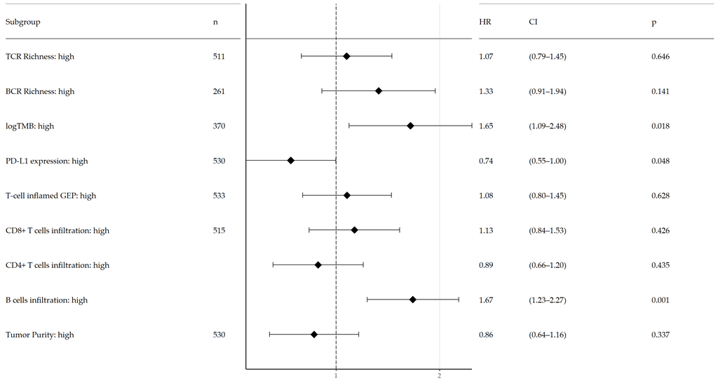

#### 4.1.3.3 BLCA

[1] “>> Subsetting data to BLCA” [1] “>>Final total if we removed missing 256 patients included<<” [1] “>>Final total 411 patients included<<” TCR_Richness BCR_Richness logTMB PD_L1 TIS_sigscore CD8cells CD4cells B_cells TumorPurity 5.00000000 9.00000000 1.73371063 7.67026470 -0.78410358 0.10993276 0.06782887 0.10999508 0.89391552 [1] “Events per categorical covariate:” TCR_Richness BCR_Richness logTMB PD_L1 TIS_sigscore CD8cells CD4cells B_cells TumorPurity 173 125 179 178 178 173 173 173 178 [1] “>>UNIVARIATE ANALYSIS<<” [1] “>>COLLECTING UNIVARIATE RESULTS<<”

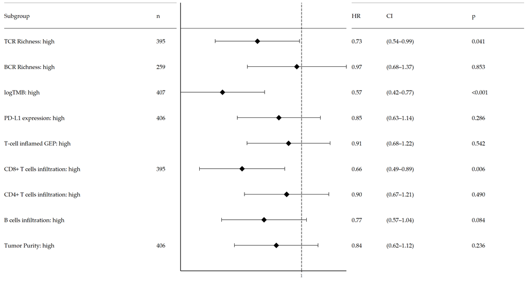

#### 4.1.3.4 STAD

[1] “>> Subsetting data to STAD” [1] “>>Final total if we removed missing 336 patients included<<” [1] “>>Final total 443 patients included<<” TCR_Richness BCR_Richness logTMB PD_L1 TIS_sigscore CD8cells CD4cells B_cells TumorPurity 95.00000000 121.00000000 1.39694572 8.24666224 -0.45834228 0.10670046 0.17179331 0.09489613 0.79509928 [1] “Events per categorical covariate:” TCR_Richness BCR_Richness logTMB PD_L1 TIS_sigscore CD8cells CD4cells B_cells TumorPurity 146 145 168 144 157 146 146 146 144 [1] “>>UNIVARIATE ANALYSIS<<” [1] “>>COLLECTING UNIVARIATE RESULTS<<”

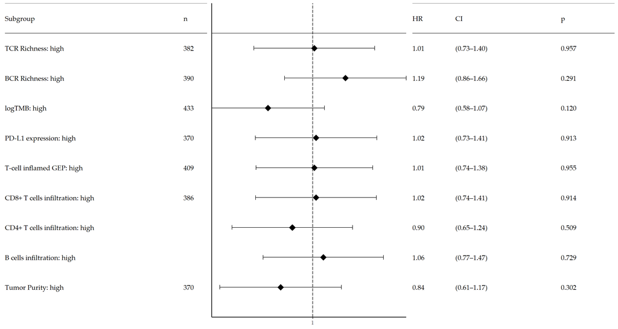

```r
# median(dataDF$TCR_Richness[!is.na(dataDF$TCR_Richness)], na.rm = TRUE)
# md <-dataDF %>% dplyr::select(TCR_Richness,OS) %>% dplyr::filter(complete.cases(.)) %>% pull(TCR_Richness) %>% median()
# md
```

# 5 Multivariable Analyses - INCLUDING MISSING DATA

Perform Cox regression on right-censored data.

## 5.1 Categorical

### 5.1.1 Across all cohorts, together

```r
multi.cat.meta <-multiUniSurvival(tcgaData.tp.sub.filt,OS_time,OS_status,"OS", featuresIn,finallabels, removeMis=FALSE, filterCohort=FALSE, filterVar=NULL,cohortSelected=NULL, categTrans=featuresIn, transBy="median",multi=TRUE)
```

### 5.1.2 All 4 histologies

```r
multi.cat.meta4 <-multiUniSurvival(tcgaData.tp.sub.filt %>% dplyr:: filter(project %in% mycancertypes.final) %>% droplevels() %>% distinct(),OS_time,OS_status,"OS", featuresIn,finallabels, removeMis=FALSE, filterCohort=FALSE, filterVar=NULL,cohortSelected=NULL, categTrans=featuresIn, transBy="median",multi=TRUE)
```

[1] “>>Final total if we removed missing 830 patients included<<” [1] “>>Final total 1838 patients included<<” TCR_Richness BCR_Richness logTMB PD_L1 TIS_sigscore CD8cells CD4cells B_cells TumorPurity 24.00000000 25.00000000 1.26274422 8.21138646 -0.43433546 0.13270135 0.10572672 0.07023504 0.77377119 [1] “Events per covariate:” [1] 36 [1] “>>MULTIVARIATE ANALYSIS<<” [1] “>>COLLECTING MULTIVARIATE RESULTS<<”

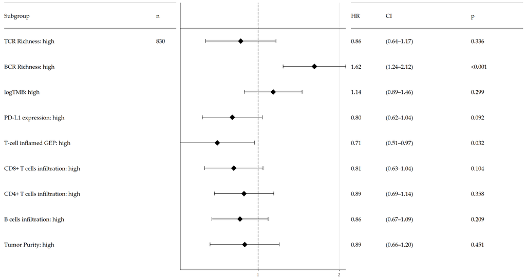

### 5.1.3 4 histologies

```r
multi.cat.4  <- sapply(mycancertypes.final, function(x) multiUniSurvival(tcgaData.tp.sub.filt,OS_time,OS_status,"OS", featuresIn,finallabels, removeMis=FALSE, filterCohort=TRUE, filterVar="project",cohortSelected=x, categTrans=featuresIn, transBy="median",multi=TRUE),simplify = FALSE)
```

#### 5.1.3.1 SKCM

[1] “>> Subsetting data to SKCM” [1] “>>Final total if we removed missing 56 patients included<<” [1] “>>Final total 449 patients included<<” TCR_Richness BCR_Richness logTMB PD_L1 TIS_sigscore CD8cells CD4cells B_cells TumorPurity 13.50000000 24.50000000 2.12957648 7.49534093 -0.78502993 0.15434100 0.04178992 0.07206350 0.89359684 [1] “Events per covariate:” [1] 1.555556 [1] “>>Less than 7 events per covariate, skipping…<<”

#### 5.1.3.2 KIRC

[1] “>> Subsetting data to KIRC” [1] “>>Final total if we removed missing 182 patients included<<” [1] “>>Final total 535 patients included<<” TCR_Richness BCR_Richness logTMB PD_L1 TIS_sigscore CD8cells CD4cells B_cells TumorPurity 33.0000000 6.0000000 0.8499441 8.4755185 -0.2456237 0.1567477 0.1382614 0.0414214 0.6809039 [1] “Events per covariate:” [1] 6.555556 [1] “>>Less than 7 events per covariate, skipping…<<”

#### 5.1.3.3 BLCA

[1] “>> Subsetting data to BLCA” [1] “>>Final total if we removed missing 256 patients included<<” [1] “>>Final total 411 patients included<<” TCR_Richness BCR_Richness logTMB PD_L1 TIS_sigscore CD8cells CD4cells B_cells TumorPurity 5.00000000 9.00000000 1.73371063 7.67026470 -0.78410358 0.10993276 0.06782887 0.10999508 0.89391552 [1] “Events per covariate:” [1] 13.66667 [1] “>>MULTIVARIATE ANALYSIS<<” [1] “>>COLLECTING MULTIVARIATE RESULTS<<”

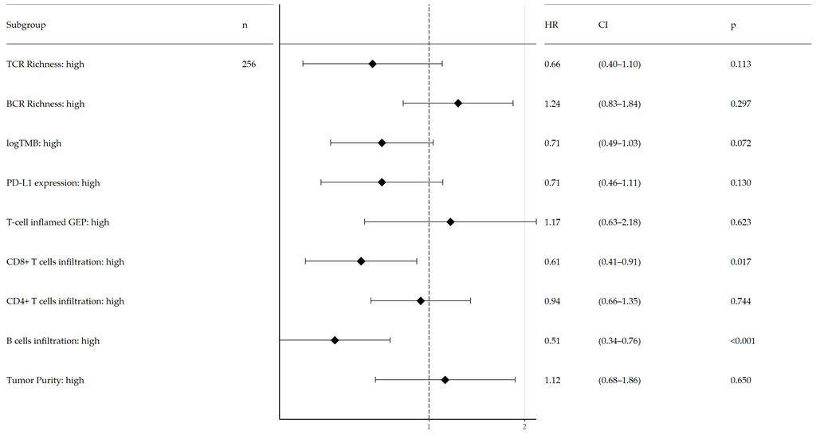

#### 5.1.3.4 STAD

[1] “>> Subsetting data to STAD” [1] “>>Final total if we removed missing 336 patients included<<” [1] “>>Final total 443 patients included<<” TCR_Richness BCR_Richness logTMB PD_L1 TIS_sigscore CD8cells CD4cells B_cells TumorPurity 95.00000000 121.00000000 1.39694572 8.24666224 -0.45834228 0.10670046 0.17179331 0.09489613 0.79509928 [1] “Events per covariate:” [1] 14.22222 [1] “>>MULTIVARIATE ANALYSIS<<” [1] “>>COLLECTING MULTIVARIATE RESULTS<<”

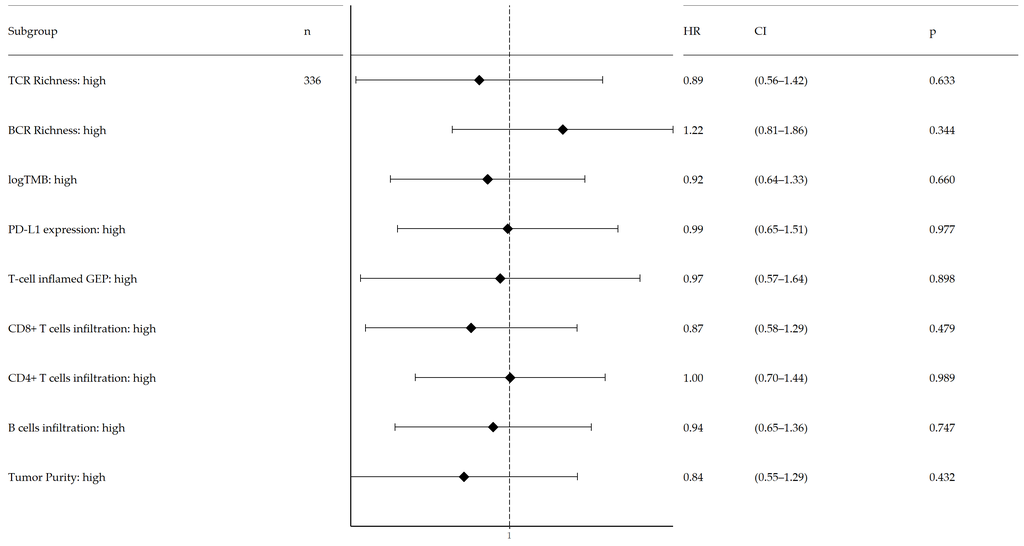

# 6 Multivariate survival with bootstrapping

Calculating bootstrapped p values and CIs, as well as bootstrapped survival models with backward selection.

```r
multi.boot <- sapply(mycancertypes.final, function(x) multiSurv.BackIndepBoot(tcgaData.tp.sub.filt,OS_time,OS_status,"OS", featuresIn,finallabels, removeMis=FALSE, filterCohort=TRUE, filterVar="project",cohortSelected=x, categTrans=featuresIn, transBy="median",multi=TRUE,scale=FALSE,alreadyCat=NULL,bootFreq=0.2),simplify = FALSE)
```

```
##
##
## ####  SKCM
##
## [1] ">> Subsetting data to SKCM\n"
## [1] ">>Final total 56 patients included<<\n"
## TCR_Richness BCR_Richness       logTMB        PD_L1 TIS_sigscore     CD8cells     CD4cells      B_cells  TumorPurity
##  13.50000000  24.50000000   2.12957648   7.49534093  -0.78502993   0.15434100   0.04178992   0.07206350   0.89359684
## [1] "Events per covariate:"
## [1] 1.555556
## [1] ">>Less than 7 events per covariate, skipping...<<\n"
##
##
## ####  KIRC
##
## [1] ">> Subsetting data to KIRC\n"
## [1] ">>Final total 182 patients included<<\n"
## TCR_Richness BCR_Richness       logTMB        PD_L1 TIS_sigscore     CD8cells     CD4cells      B_cells  TumorPurity
##   33.0000000    6.0000000    0.8499441    8.4755185   -0.2456237    0.1567477    0.1382614    0.0414214    0.6809039
## [1] "Events per covariate:"
## [1] 6.555556
## [1] ">>Less than 7 events per covariate, skipping...<<\n"
##
##
## ####  BLCA
##
## [1] ">> Subsetting data to BLCA\n"
## [1] ">>Final total 256 patients included<<\n"
## TCR_Richness BCR_Richness       logTMB        PD_L1 TIS_sigscore     CD8cells     CD4cells      B_cells  TumorPurity
##   5.00000000   9.00000000   1.73371063   7.67026470  -0.78410358   0.10993276   0.06782887   0.10999508   0.89391552
## [1] "Events per covariate:"
## [1] 13.66667
## [1] ">>Calculing bootstrapped pvals &  CIs...<<\n"
## Using exponentiated coefficients.
##
##
## ####  STAD
##
## [1] ">> Subsetting data to STAD\n"
## [1] ">>Final total 336 patients included<<\n"
## TCR_Richness BCR_Richness       logTMB        PD_L1 TIS_sigscore     CD8cells     CD4cells      B_cells  TumorPurity
##  95.00000000 121.00000000   1.39694572   8.24666224  -0.45834228   0.10670046   0.17179331   0.09489613   0.79509928
## [1] "Events per covariate:"
## [1] 14.22222
## [1] ">>Calculing bootstrapped pvals &  CIs...<<\n"
## Using exponentiated coefficients.
```

# 7 Save data

```r
## SAVE DATA
### UNIVARIATE
## CATEGORICAL

save(uni.cat.meta4, file = paste0(projectOutDataPath,"survival/","uni.cat.meta4.TCGA",Rdata.suffix))
save(uni.cat.4, file = paste0(projectOutDataPath,"survival/","uni.cat.4.TCGA",Rdata.suffix))


### MULTIVARIATE
## CATEGORICAL
save(multi.cat.meta4, file = paste0(projectOutDataPath,"survival/","multi.cat.meta4.TCGA",Rdata.suffix))
save(multi.cat.4, file = paste0(projectOutDataPath,"survival/","multi.cat.4.TCGA",Rdata.suffix))

# Multivariate bootstrapping
save(multi.boot, file = paste0(projectOutDataPath,"survival/","multi.cat.BOOT.TCGA",Rdata.suffix))
```

# 8 Session Info

```r
writeLines(capture.output(session_info), paste0(sessionInfoPath,"C_01_TCGA_survival_analysis.txt"))
```